# Martingale posteriors. Inspecting the prior

David Rossell

2022-11-09

# Bernoulli example

We wish to estimate the expectation $E(Y_i)$ where $Y_i \sim Bern(\theta)$ independently across $i$, given the observed values $y_1,\ldots,y_n$.

## Define auxiliary functions

We start by defining the function `thetafun` that computes $\theta$ given $y=(y_1,\ldots,y_n,y_{n+1},\ldots,y_{n+N})$, where $(y_{n+1},\ldots,y_{n+N})$ are posterior predictive draws given $y_1,\ldots,y_n$.

```r
thetafun= function(y) mean(y)
```

We next define a function `postpred` that obtains `npost` posterior draws from $\pi(\theta \mid y_1,\ldots,y_n)$. This is achieved by producing, for each desired posterior draw, a posterior predictive sample of size $N$ (argument `npred`). The posterior predictive sample is obtained from the Dirichlet-bootstrap posterior predictive.

```r
postpred= function(y, npred, npost, thetafun) {
    #Obtain npost posterior samples using npred samples from the Dirichlet-bootstrap posterior predictive
    # - y: observed data
    # - npred: number of observations from posterior predictive
    # - npost: number of posterior samples
    # - thetafun: function that returns theta given (y, ypred)
    require(VGAM)
    n= length(y)
    theta= matrix(NA, nrow=npost, ncol=1)
    for (i in 1:npost) {
        w= rdiric(1, shape=rep(1,n))
        ypred= sample(y, size=npred, replace=TRUE, prob=w)
        theta[i]= thetafun(c(y,ypred))
        if ((i %% 1000)==0) cat('.')
    }
    return(theta)
}
```

Finally, we define a function to evaluate the Bernoulli likelihood function at $\theta$ given $y_1,\ldots,y_n$.

```r
lhood= function(theta, y, logscale=TRUE) {
    ans= double(length(theta))
    for (i in 1:length(theta)) ans[i]= sum(dbinom(y, size=1, prob=theta[i], log=logscale))
    return(ans)
}
```

## A simulated dataset

We consider a moderately large sample size $n=100$ and setting where truly $\theta=0.5$. We obtain 100,000 posterior samples, each based on a posterior predictive sample of size $N=10,000$. We set the random number generator seed to that our results are reproducible.

```r
set.seed(1)
n= 100; theta=0.5; npred= 10^4; npost= 10^5
y= (runif(n)<theta)
theta= postpred(y=y, npred=npred, npost=npost, thetafun=thetafun)
```

```
## ....................................................................................................
```

We next evaluate the likelihood on a grid of $\theta$ values, as well as the estimated posterior density. To obtain the latter we use a Kernel density estimator in function `pvaldens` of R package `bootruin` (it is based on Beta kernels, since the posterior support is [0,1]).

```r
library(bootruin)
binwidth= 0.002
thmin= 0.25; thmax= 0.75
thgrid= seq(thmin + 0.5*binwidth, thmax - 0.5*binwidth, by=binwidth)
thlhood= lhood(thgrid, y=y, logscale=TRUE)
```

```r
posteriorfun= pvaldens(theta,method='chen')
thpost= double(length(thgrid))
for (i in 1:length(thpost)) thpost[i]= posteriorfun(thgrid[i])
```

Finally, we estimate the prior $\pi(\theta) \propto \pi(\theta \mid y_1,\ldots,y_n) / p(y_1,\ldots,y_n \mid \theta)$, where $p(y_1,\ldots,y_n \mid \theta)$ is the likelihood function.

```r
thprior= thpost / exp(thlhood)
```

The estimated prior density might be inaccurate for values of $\theta$ where the estimated posterior is near-zero, to avoid such issues we focus on $\theta$ values with estimated posterior density above a 0.001 threshold.

```r
sel= (thpost > 0.001)
thpost= thpost[sel]
thprior= thprior[sel]
thlhood= thlhood[sel]
thgrid= thgrid[sel]
```

Finally, for plotting purposes we re-normalize the posterior and prior densities to add to 1 over the grid values, and we re-scale the likelihood function to match the maximum height of the posterior density.

```r
thpost= thpost/sum(thpost)
thprior= thprior/sum(thprior)
thlhood= exp(thlhood)*max(thpost)/max(exp(thlhood))
```

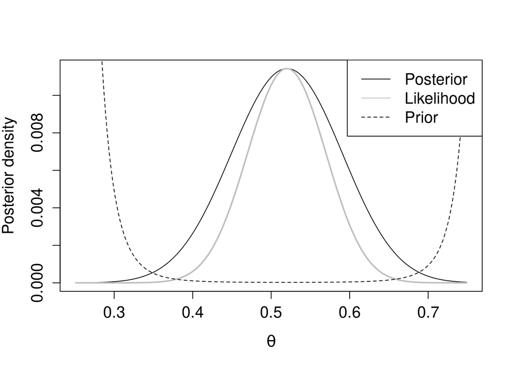

```r
plot(thgrid, thpost, type='l', xlab=expression(theta), ylab='Posterior density', cex.lab=1.3, cex.axis=1.3)
lines(thgrid, thlhood, col='gray', lwd=2)
lines(thgrid, thprior, lty=2)
legend('topright', c('Posterior','Likelihood','Prior'), col=c(1,'gray',1), lty=c(1,1,2), cex=1.3)
```

# Gaussian example

We wish to estimate the expectation $E(Y_i)$ where $Y_i \sim N(\theta,1)$ independently across $i$, given the observed values $y_1,\ldots,y_n$.

## Define auxiliary functions

Analogously to Section 1, we define the likelihood function `lhood` (functions `thetafun`, `postpred` remain the same as in Section 1).

```r
thetafun= function(y) mean(y)
```

```r
lhood= function(theta, y, logscale=TRUE) {
    ans= double(length(theta))
    for (i in 1:length(theta)) ans[i]= sum(dnorm(y, mean=theta[i], sd=1, log=logscale))
    return(ans)
}
```

## A simulated dataset

We simulate a dataset with $n=100$ observations where truly $\theta=5$. We set the random number generator seed to ensure that our results are reproducible.

```r
set.seed(1)
n= 100; mu= 5; npred= 10^4; npost= 10^5
y= rnorm(n, mean=mu)
theta= postpred(y=y, npred=npred, npost=npost, thetafun=thetafun)
```

```
## ....................................................................................................
```

To estimate the posterior density at a grid of $\theta$ values we use the mixture of normals estimator implemented in `densityMclust` (R package `mclust`).

```r
library(mclust)
thmin= 4; thmax= 6.5
th= seq(thmin, thmax, length=200)
thlhood= lhood(th, y=y, logscale=TRUE)
d2= densityMclust(theta, plot=FALSE)
thpost= predict(d2, newdata=th)
```

We obtain the estimated prior density at a given $\theta$ as being proportional to the ratio of the posterior density at $\theta$ divided by the likelihood at $\theta$.

```r
thprior= thpost / exp(thlhood - max(thlhood))
```

Finally, for plotting purposes we re-normalize the posterior and prior densities to add to 1 over the grid values, and we re-scale the likelihood function to match the maximum height of the posterior density.

```r
thpost= thpost/sum(thpost)
thprior= thprior/sum(thprior)
thlhood= exp(thlhood)*max(thpost)/max(exp(thlhood))
```

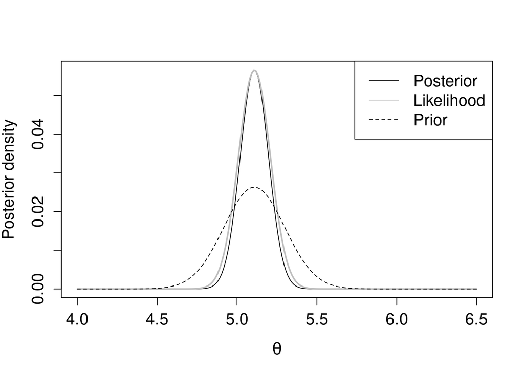

```r
plot(th, thpost, type='l', xlab=expression(theta), ylab='Posterior density', cex.lab=1.3, cex.axis=1.3)
lines(th, thlhood, col='gray', lwd=2)
lines(th, thprior, lty=2)
legend('topright', c('Posterior','Likelihood','Prior'), col=c(1,'gray',1), lty=c(1,1,2), cex=1.3)
```